# HW8

Author

Kevin Cendana

### **1**

**Write a function that initializes the disease simulation by randomly infecting some proportion of the population. The function should accept these arguments:**

- **number of rows in the grid**
- **number of columns in the grid**
- **proportion of grid to start out infected, defaulting to 0.1.**

```r
initialize_grid <- function(rows, cols, proportion = 0.1) {
  # calculate total # of cells & number of people infected
  total_cells <- rows * cols
  num_infected <- round(total_cells * proportion)

  # use those to create vector
  initial_states <- c(rep(1, num_infected), rep(0, total_cells - num_infected))

  # shuffle the vector to randomize data
  initial_states <- sample(initial_states)

  # convert the vector to a matrix to represent a grid, return
  grid <- matrix(initial_states, nrow = rows, ncol = cols)
  grid
}

# test data - show small array for now then plot in the next question
simulation_grid_test <- initialize_grid(rows = 10, cols = 10, proportion = 0.1)
simulation_grid_test
```

```
      [,1] [,2] [,3] [,4] [,5] [,6] [,7] [,8] [,9] [,10]
 [1,]    0    0    0    0    0    0    0    0    1     0
 [2,]    0    0    0    0    0    1    0    0    0     0
 [3,]    0    0    0    0    0    0    0    0    0     0
 [4,]    0    0    0    0    0    0    0    0    0     0
 [5,]    0    0    0    0    0    0    0    1    0     0
 [6,]    0    0    0    0    0    0    0    0    0     0
 [7,]    0    0    0    0    1    0    0    0    1     0
 [8,]    0    0    0    0    1    0    0    0    0     0
 [9,]    0    0    0    0    0    1    0    0    0     1
[10,]    0    0    0    0    1    0    1    0    0     0
```

### **2**

```r
plot_simulation_grid <- function(grid, title = "Simulation Grid") {
  # colors for each state: susceptible (0), infected (1), removed (2)
  state_colors <- c("white", "grey", "red")

  # ensure the grid is transposed (mandatory for the image function)
  transposed_grid <- t(grid)

  # plot the grid without axes and w/ aspect ratio 1
  image(1:ncol(transposed_grid), 1:nrow(transposed_grid), transposed_grid, col = state_colors, axes = FALSE, xlab = '', ylab = '', asp = 1, main = title)
}

  # initialize an 80x80 grid with a 10% infection rate
simulation_grid <- initialize_grid(rows = 50, cols = 50, proportion = 0.1)

# verify the number of each state in the grid
table(simulation_grid)
```

```
simulation_grid
   0    1
2250  250
```

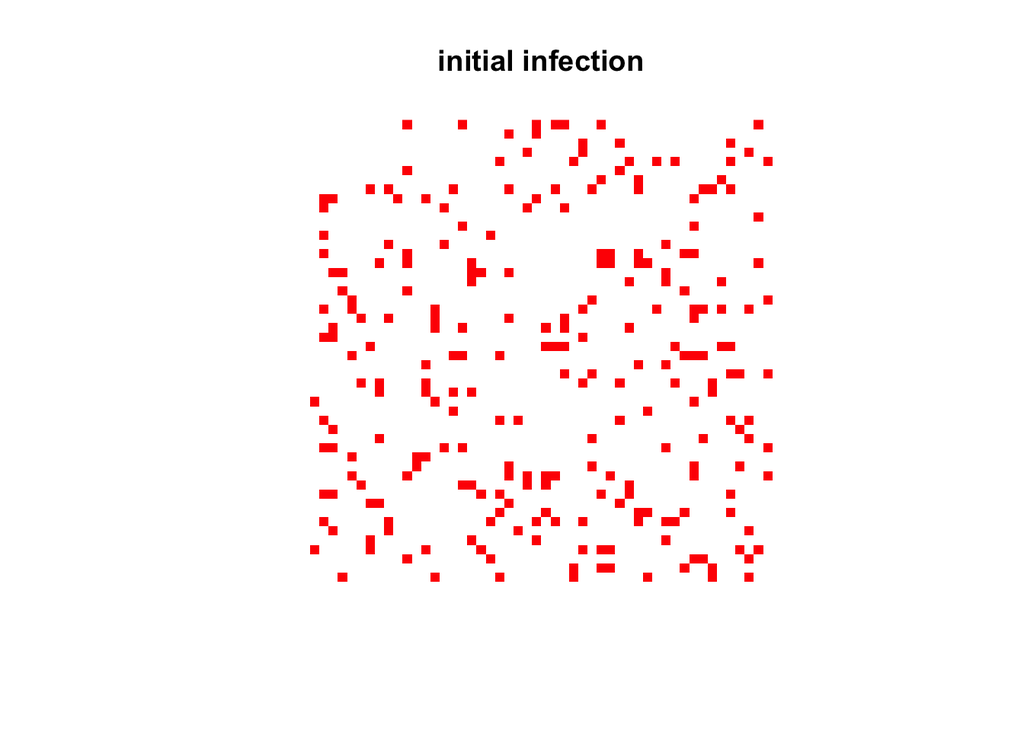

```r
# plot the grid
plot_simulation_grid(simulation_grid, "initial infection")
```

### **3**

**Use vectorized code (not a for loop) to randomly infect approximately 50% of the cells EITHER ABOVE OR BELOW the infected cells. This is part of one step in the process. A full step will expose 8 neighboring cells to infection: 4 sides, and 4 corners.**

**Plot your results to demonstrate correctness.**

1. **Use par(mfrow = c(1, 2)) for two side by side plots.**
2. **Index into the matrix by selecting all elements excluding the first or last row.**

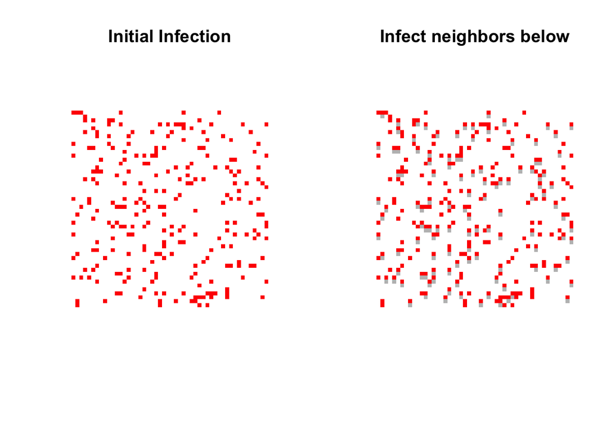

```r
# initialize the grid w/ a small proportion of infected cells
set.seed(492)  # for reproducibility
initial_grid <- initialize_grid(rows = 50, cols = 50, proportion = 0.1)

# generate a close contact matrix for cells above/below the infected cells
prob_infect = 0.5  # have rng decide above or below
cc_below <- matrix(sample(c(FALSE, TRUE), size = (nrow(initial_grid) - 1) * ncol(initial_grid), replace = TRUE, prob = c(1 - prob_infect, prob_infect)), nrow = nrow(initial_grid) - 1, ncol = ncol(initial_grid))

# determine new infections based on contact, only below infected cells
new_infections_below <- (initial_grid[-1, ] == 1) & cc_below

# update the grid with new infections
updated_grid <- initial_grid
updated_grid[-nrow(updated_grid), ][new_infections_below] <- 1

# change the state of previously infected cells to removed
updated_grid[initial_grid == 1] <- 2

# plot the initial and updated grids side by side
par(mfrow = c(1, 2))
plot_simulation_grid(initial_grid, "Initial Infection")
plot_simulation_grid(updated_grid, "Infect neighbors below")
```

**4**

**Extend the step above to all 8 neighbors of a cell by writing a function that performs a single infection step. The rule is that each infected cell infects susceptible neighbors with some fixed probability. Vectorized code or explicit for loops are both fine. The function should accept the following:**

1. **Data structure representing the current SIR (susceptible, infected, removed) state. This will be a matrix if you’re following the standard advice. 🤔**
2. **Probability of infection, defaulting to 0.125**

**Plot your results for a single step to demonstrate correctness. Your plot should resemble the one below, with new infections occurring randomly on all sides and corners of old infections.**

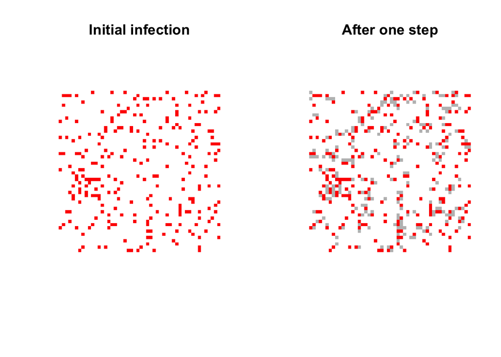

```r
# function to perform just 1 infection step
infect_neighbors <- function(grid, prob_infect = 0.125) {
  # seed the random number generator for reproducibility in this example
  set.seed(492)

  # generate random close contact boolean matrices for each direction
  cc_right <- matrix(sample(c(FALSE, TRUE), size = nrow(grid) * (ncol(grid) - 1), replace = TRUE, prob = c(1 - prob_infect, prob_infect)), nrow = nrow(grid))
  cc_left <- cc_right  # same dimensions for left
  cc_up <- matrix(sample(c(FALSE, TRUE), size = (nrow(grid) - 1) * ncol(grid), replace = TRUE, prob = c(1 - prob_infect, prob_infect)), ncol = ncol(grid))
  cc_down <- cc_up  # same dimensions for down
  cc_diag <- matrix(sample(c(FALSE, TRUE), size = (nrow(grid) - 1) * (ncol(grid) - 1), replace = TRUE, prob = c(1 - prob_infect, prob_infect)), nrow = nrow(grid) - 1)

  # create a copy of the grid to update with new infections
  xnew <- grid

  # infect right/left/up/down neighbors
  xnew[, -ncol(grid)][cc_right & grid[, -1] == 1] <- 1
  xnew[, -1][cc_left & grid[, -ncol(grid)] == 1] <- 1
  xnew[-1, ][cc_up & grid[-nrow(grid), ] == 1] <- 1
  xnew[-nrow(grid), ][cc_down & grid[-1, ] == 1] <- 1

  # infect diagonal neighbors
  xnew[-1, -1][cc_diag & grid[-nrow(grid), -ncol(grid)] == 1] <- 1
  xnew[-1, -ncol(grid)][cc_diag & grid[-nrow(grid), -1] == 1] <- 1
  xnew[-nrow(grid), -1][cc_diag & grid[-1, -ncol(grid)] == 1] <- 1
  xnew[-nrow(grid), -ncol(grid)][cc_diag & grid[-1, -1] == 1] <- 1

  # remove those who were formerly infected on the previous step
  xnew[grid == 1] <- 2

  xnew
}

# set up the plotting area for two side-by-side plots
par(mfrow = c(1, 2))

# initialize the grid with a small proportion of infected cells
initial_grid <- initialize_grid(rows = 50, cols = 50, proportion = 0.1)

# run the infection step function
updated_grid <- infect_neighbors(initial_grid)

# plot initial and updated grid
plot_simulation_grid(initial_grid, "Initial infection")
plot_simulation_grid(updated_grid, "After one step")
```